# Final DAND PROJECT

## communicate-data-project-template : fordgobike dataset

## __important__

the main scope of this project is to see if there is any behaviour difference between usage depending on age,gender,and user_type

```python
# import all packages and set plots to be embedded inline
import numpy as np
import pandas as pd
import matplotlib.pyplot as plt
import seaborn as sb
import warnings


warnings.filterwarnings('ignore')
%matplotlib inline
```

> Load in your dataset and describe its properties through the questions below. Try and motivate your exploration goals through this section.

```python
df = pd.read_csv("201902-fordgobike-tripdata.csv")
```

```python
df_backup = df.copy()
```

```python
df.head()
```

|  | duration_sec | start_time | end_time | start_station_id | start_station_name | start_station_latitude | start_station_longitude | end_station_id | end_station_name | end_station_latitude | end_station_longitude | bike_id | user_type | member_birth_year | member_gender | bike_share_for_all_trip |
| --- | --- | --- | --- | --- | --- | --- | --- | --- | --- | --- | --- | --- | --- | --- | --- | --- |
| 0 | 52185 | 2019-02-28 17:32:10.1450 | 2019-03-01 08:01:55.9750 | 21.0 | Montgomery St BART Station (Market St at 2nd St) | 37.789625 | -122.400811 | 13.0 | Commercial St at Montgomery St | 37.794231 | -122.402923 | 4902 | Customer | 1984.0 | Male | No |
| 1 | 42521 | 2019-02-28 18:53:21.7890 | 2019-03-01 06:42:03.0560 | 23.0 | The Embarcadero at Steuart St | 37.791464 | -122.391034 | 81.0 | Berry St at 4th St | 37.775880 | -122.393170 | 2535 | Customer | NaN | NaN | No |
| 2 | 61854 | 2019-02-28 12:13:13.2180 | 2019-03-01 05:24:08.1460 | 86.0 | Market St at Dolores St | 37.769305 | -122.426826 | 3.0 | Powell St BART Station (Market St at 4th St) | 37.786375 | -122.404904 | 5905 | Customer | 1972.0 | Male | No |
| 3 | 36490 | 2019-02-28 17:54:26.0100 | 2019-03-01 04:02:36.8420 | 375.0 | Grove St at Masonic Ave | 37.774836 | -122.446546 | 70.0 | Central Ave at Fell St | 37.773311 | -122.444293 | 6638 | Subscriber | 1989.0 | Other | No |
| 4 | 1585 | 2019-02-28 23:54:18.5490 | 2019-03-01 00:20:44.0740 | 7.0 | Frank H Ogawa Plaza | 37.804562 | -122.271738 | 222.0 | 10th Ave at E 15th St | 37.792714 | -122.248780 | 4898 | Subscriber | 1974.0 | Male | Yes |

```python
df.shape
```

```
(183412, 16)
```

```python
df.info()
```

```
<class 'pandas.core.frame.DataFrame'>
RangeIndex: 183412 entries, 0 to 183411
Data columns (total 16 columns):
 #   Column                   Non-Null Count   Dtype
---  ------                   --------------   -----
 0   duration_sec             183412 non-null  int64
 1   start_time               183412 non-null  object
 2   end_time                 183412 non-null  object
 3   start_station_id         183215 non-null  float64
 4   start_station_name       183215 non-null  object
 5   start_station_latitude   183412 non-null  float64
 6   start_station_longitude  183412 non-null  float64
 7   end_station_id           183215 non-null  float64
 8   end_station_name         183215 non-null  object
 9   end_station_latitude     183412 non-null  float64
 10  end_station_longitude    183412 non-null  float64
 11  bike_id                  183412 non-null  int64
 12  user_type                183412 non-null  object
 13  member_birth_year        175147 non-null  float64
 14  member_gender            175147 non-null  object
 15  bike_share_for_all_trip  183412 non-null  object
dtypes: float64(7), int64(2), object(7)
memory usage: 22.4+ MB
```

```python
df.describe()
```

|  | duration_sec | start_station_id | start_station_latitude | start_station_longitude | end_station_id | end_station_latitude | end_station_longitude | bike_id | member_birth_year |
| --- | --- | --- | --- | --- | --- | --- | --- | --- | --- |
| count | 183412.000000 | 183215.000000 | 183412.000000 | 183412.000000 | 183215.000000 | 183412.000000 | 183412.000000 | 183412.000000 | 175147.000000 |
| mean | 726.078435 | 138.590427 | 37.771223 | -122.352664 | 136.249123 | 37.771427 | -122.352250 | 4472.906375 | 1984.806437 |
| std | 1794.389780 | 111.778864 | 0.099581 | 0.117097 | 111.515131 | 0.099490 | 0.116673 | 1664.383394 | 10.116689 |
| min | 61.000000 | 3.000000 | 37.317298 | -122.453704 | 3.000000 | 37.317298 | -122.453704 | 11.000000 | 1878.000000 |
| 25% | 325.000000 | 47.000000 | 37.770083 | -122.412408 | 44.000000 | 37.770407 | -122.411726 | 3777.000000 | 1980.000000 |
| 50% | 514.000000 | 104.000000 | 37.780760 | -122.398285 | 100.000000 | 37.781010 | -122.398279 | 4958.000000 | 1987.000000 |
| 75% | 796.000000 | 239.000000 | 37.797280 | -122.286533 | 235.000000 | 37.797320 | -122.288045 | 5502.000000 | 1992.000000 |
| max | 85444.000000 | 398.000000 | 37.880222 | -121.874119 | 398.000000 | 37.880222 | -121.874119 | 6645.000000 | 2001.000000 |

we are only going to use some of the columns,so let's remove the ones that we are not going to use

```python
df_use = df[["duration_sec","start_time","end_time","start_station_name","end_station_name","bike_id","user_type","member_birth_year","member_gender"]]
```

```python
df_use.head()
```

|  | duration_sec | start_time | end_time | start_station_name | end_station_name | bike_id | user_type | member_birth_year | member_gender |
| --- | --- | --- | --- | --- | --- | --- | --- | --- | --- |
| 0 | 52185 | 2019-02-28 17:32:10.1450 | 2019-03-01 08:01:55.9750 | Montgomery St BART Station (Market St at 2nd St) | Commercial St at Montgomery St | 4902 | Customer | 1984.0 | Male |
| 1 | 42521 | 2019-02-28 18:53:21.7890 | 2019-03-01 06:42:03.0560 | The Embarcadero at Steuart St | Berry St at 4th St | 2535 | Customer | NaN | NaN |
| 2 | 61854 | 2019-02-28 12:13:13.2180 | 2019-03-01 05:24:08.1460 | Market St at Dolores St | Powell St BART Station (Market St at 4th St) | 5905 | Customer | 1972.0 | Male |
| 3 | 36490 | 2019-02-28 17:54:26.0100 | 2019-03-01 04:02:36.8420 | Grove St at Masonic Ave | Central Ave at Fell St | 6638 | Subscriber | 1989.0 | Other |
| 4 | 1585 | 2019-02-28 23:54:18.5490 | 2019-03-01 00:20:44.0740 | Frank H Ogawa Plaza | 10th Ave at E 15th St | 4898 | Subscriber | 1974.0 | Male |

## Univariate Exploration

> In this section, investigate distributions of individual variables. If you see unusual points or outliers, take a deeper look to clean things up and prepare yourself to look at relationships between variables.

let's see the ratio of subscribers

```python
def pie_ratio_type_users() :
    count = df_use["user_type"].value_counts()
    count
    labels=["Subscriber","Customer"]
    plt.figure(figsize= (10,10))
    plt.title("Ration of customers and subscribers")
    plt.pie(count,labels=labels,startangle=90,autopct='%1.3f %%');
```

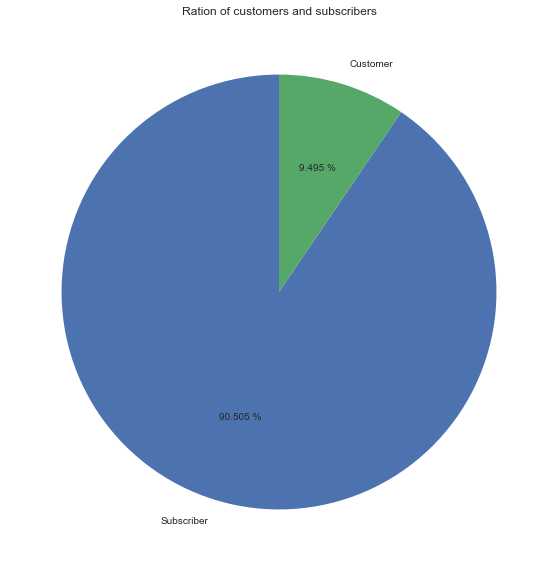

```python
pie_ratio_type_users()
```

to facilitate our work we will create new variable like start_month,start_hour ect

```python
df_use["start_month"] = df["start_time"].apply(lambda x:x.split("-")[1]);
df_use["end_month"] = df["end_time"].apply(lambda x:x.split("-")[1]);
df_use["start_hour"] = df["start_time"].apply(lambda x:x.split("-")[2].split()[1].split(":")[0])
df_use["end_hour"] = df["end_time"].apply(lambda x:x.split("-")[2].split()[1].split(":")[0])
```

we will not be working with the columns "start_time" and "end_time" so we will remove them

```python
df_use.drop(["start_time","end_time"],axis = 1,inplace= True)
```

let's see the average duration time

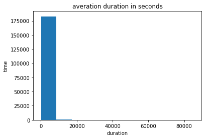

```python
plt.hist(df_use["duration_sec"])
plt.title("averation duration in seconds")
plt.xlabel("duration")
plt.ylabel("time")
```

as we can see the plot does not provide clear informations probably because of the presence of some outliers,let's try to make a limit

```python
print("mean of duration is : " ,df_use["duration_sec"].mean())
print("max of duration is : " ,df_use["duration_sec"].max())
```

```
mean of duration is :  726.078435434977
max of duration is :  85444
```

the mean is very far from the max value,let's try to do the logarithme instead

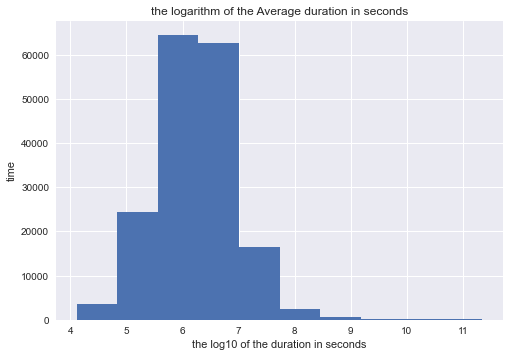

```python
plt.hist(df_use["duration_sec"].apply('log'))
plt.xlabel("the log10 of the duration in seconds")
plt.ylabel("time")
plt.title("the logarithm of the Average duration in seconds")
```

```python
def rides_hour():
    plt.figure(figsize = (20, 10))
    color = sb.color_palette()[0]
    sb.countplot(data = df_use.sort_values(by='start_hour'), x = 'start_hour', color = color);
    plt.title('Number of rides depending on the hour', fontsize = 18);
    g.set_xlabels('hour in 24h format')
    g.set_ylabels('number of rider')
```

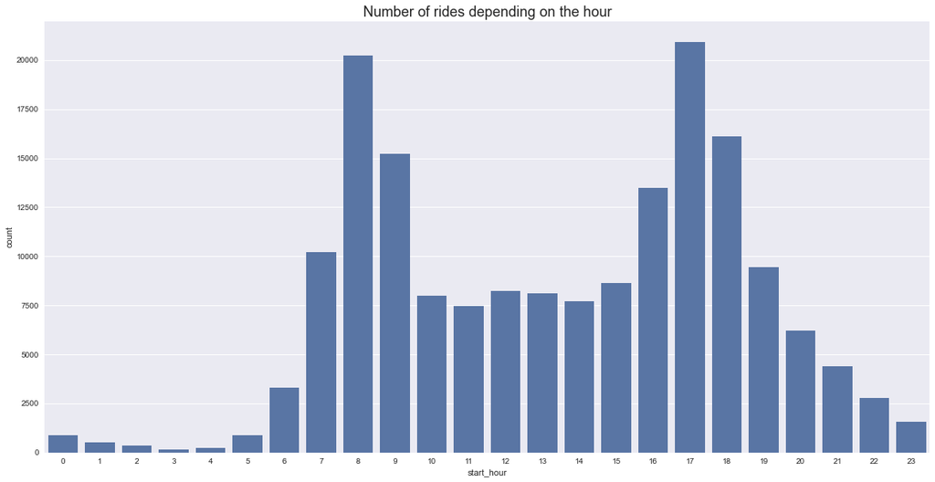

```python
rides_hour()
```

as expected the most usage is beetween 8h and 18h with a peak at the two extremes probably because that most people a going back homes from their jobs

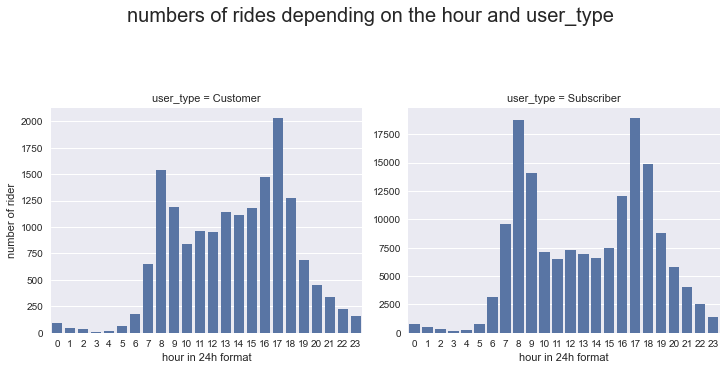

```python
df_use["start_hour"] = df_use["start_hour"].astype(int)
hours = [v for v in range (0,24)]
g = sb.catplot(data=df_use, x='start_hour', col="user_type", kind='count', sharey = False,order=hours,color = color)
g.set_xlabels('hour in 24h format')
g.set_ylabels('number of rider')
g.fig.subplots_adjust(top=0.7)
g.fig.suptitle('numbers of rides depending on the hour and user_type',size = 20)
```

we can see that both customers and subsribers behaviours folows aproximatly the same trends

```python
gender_counts = df_use["member_gender"].value_counts()
gender_counts
```

```
Male      130651
Female     40844
Other       3652
Name: member_gender, dtype: int64
```

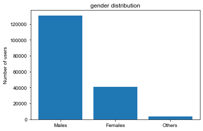

```python
plt.bar(['Males', 'Females',"Others"],[gender_counts["Male"], gender_counts["Female"],gender_counts["Other"]]);
plt.title('gender distribution');
plt.ylabel('Number of users');
plt.style.use('seaborn')
```

as we can see here the proportion of males is way biggers than the two others

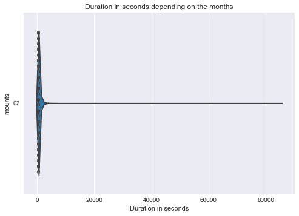

```python
sb.violinplot(data=df_use, y='start_month', x='duration_sec', inner='quartile',color=color)
plt.xlabel('Duration in seconds')
plt.ylabel('mounts')
plt.title('Duration in seconds depending on the months');
```

it took me a lot of time to realise that all the entries in the dataset are from the same mounth thus making the "start_month" and "end_month" useless,but i'm leaving them as a record of my work

let's see if we can find something from hte age of the users,to have more clearer plots we are going to use age range instead

```python
df_use.dropna(subset = ["member_birth_year"],inplace=True)
```

```python
df_use["membre_age"] = 2019 - df_use["member_birth_year"]
```

```python
df_use["membre_age_range"] = df_use["membre_age"].copy()
```

```python
df_use.dropna(subset = ["membre_age_range","membre_age"])
```

|  | duration_sec | start_station_name | end_station_name | bike_id | user_type | member_birth_year | member_gender | start_month | end_month | start_hour | end_hour | membre_age | membre_age_range |
| --- | --- | --- | --- | --- | --- | --- | --- | --- | --- | --- | --- | --- | --- |
| 0 | 52185 | Montgomery St BART Station (Market St at 2nd St) | Commercial St at Montgomery St | 4902 | Customer | 1984.0 | Male | 02 | 03 | 17 | 08 | 35.0 | 35.0 |
| 2 | 61854 | Market St at Dolores St | Powell St BART Station (Market St at 4th St) | 5905 | Customer | 1972.0 | Male | 02 | 03 | 12 | 05 | 47.0 | 47.0 |
| 3 | 36490 | Grove St at Masonic Ave | Central Ave at Fell St | 6638 | Subscriber | 1989.0 | Other | 02 | 03 | 17 | 04 | 30.0 | 30.0 |
| 4 | 1585 | Frank H Ogawa Plaza | 10th Ave at E 15th St | 4898 | Subscriber | 1974.0 | Male | 02 | 03 | 23 | 00 | 45.0 | 45.0 |
| 5 | 1793 | 4th St at Mission Bay Blvd S | Broadway at Kearny | 5200 | Subscriber | 1959.0 | Male | 02 | 03 | 23 | 00 | 60.0 | 60.0 |
| ... | ... | ... | ... | ... | ... | ... | ... | ... | ... | ... | ... | ... | ... |
| 183407 | 480 | Beale St at Harrison St | Union Square (Powell St at Post St) | 4832 | Subscriber | 1996.0 | Male | 02 | 02 | 00 | 00 | 23.0 | 23.0 |
| 183408 | 313 | Montgomery St BART Station (Market St at 2nd St) | 3rd St at Townsend St | 4960 | Subscriber | 1984.0 | Male | 02 | 02 | 00 | 00 | 35.0 | 35.0 |
| 183409 | 141 | The Alameda at Bush St | Morrison Ave at Julian St | 3824 | Subscriber | 1990.0 | Male | 02 | 02 | 00 | 00 | 29.0 | 29.0 |
| 183410 | 139 | San Pablo Ave at MLK Jr Way | San Pablo Ave at 27th St | 5095 | Subscriber | 1988.0 | Male | 02 | 02 | 00 | 00 | 31.0 | 31.0 |
| 183411 | 271 | Spear St at Folsom St | 2nd St at Folsom St | 1057 | Subscriber | 1989.0 | Male | 02 | 02 | 00 | 00 | 30.0 | 30.0 |

175147 rows × 13 columns

```python
i = 0
age_range_list = []
for e in df_use["membre_age"] :
    if e <= 20  :
        age_range_list.append("[0,20]")
    elif( e > 20 and e <= 30):
        age_range_list.append("[21,30]")
    elif( e > 30 and e <= 40):
        age_range_list.append("[31,40]")
    elif( e > 40 and e <= 50):
        age_range_list.append("[41,50]")
    elif( e > 50 and e <= 60):
        age_range_list.append("[51,60]")
    elif( e > 60 and e <= 70):
        age_range_list.append("[61,70]")
    elif( e > 70 and e <= 80):
        age_range_list.append("[71,80]")
    else :
        age_range_list.append("[81,+]")
```

```python
df_use["membre_age_range"] = age_range_list
```

```python
df_use["membre_age_range"] = df_use["membre_age_range"].astype("category")
```

```python
df_use.info()
```

[output not shown]

now we can finaly visualise things based on age range

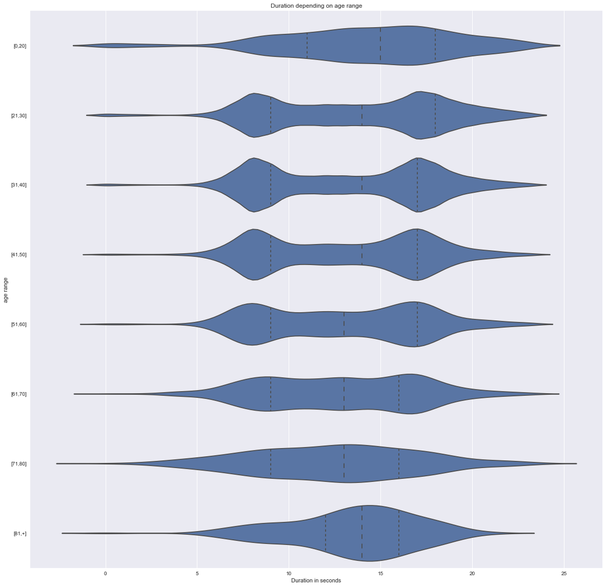

```python
plt.figure(figsize= (20,20))
sb.violinplot(data=df_use, y='membre_age_range', x='start_hour', inner='quartile',color=color)
plt.xlabel('Duration in seconds')
plt.ylabel('age range')
plt.title('Duration depending on age range');
```

let's calculate the number of rides of each age range

```python
def create_list_age_range() :
    i = 0
    age_range_dict = {"[0,20]":0,"[21,30]":0,"[31,40]":0,"[41,50]":0,"[51,60]":0,"[61,70]":0,"[71,80]":0,"[80,+]":0}

    for e in df_use["membre_age"] :
        if e <= 20  :
            age_range_dict["[0,20]"] = age_range_dict["[0,20]"] + 1
        elif( e > 20 and e <= 30):
            age_range_dict["[21,30]"] = age_range_dict["[21,30]"] + 1
        elif( e > 30 and e <= 40):
            age_range_dict["[31,40]"] = age_range_dict["[31,40]"] + 1
        elif( e > 40 and e <= 50):
            age_range_dict["[41,50]"] = age_range_dict["[41,50]"] + 1
        elif( e > 50 and e <= 60):
            age_range_dict["[51,60]"] = age_range_dict["[51,60]"] + 1
        elif( e > 60 and e <= 70):
            age_range_dict["[61,70]"] = age_range_dict["[61,70]"] + 1
        elif( e > 70 and e <= 80):
            age_range_dict["[71,80]"] = age_range_dict["[71,80]"] + 1
        else :
            age_range_dict["[80,+]"] = age_range_dict["[80,+]"] + 1
    return age_range_dict
```

```python
create_list_age_range()
```

```
{'[0,20]': 4240,
 '[21,30]': 70115,
 '[31,40]': 63886,
 '[41,50]': 22050,
 '[51,60]': 11326,
 '[61,70]': 2955,
 '[71,80]': 383,
 '[80,+]': 192}
```

let's visualse them in a barchart

```python
age_range_dict = create_list_age_range()
labels = list(age_range_dict.keys())
values = list(age_range_dict.values())
```

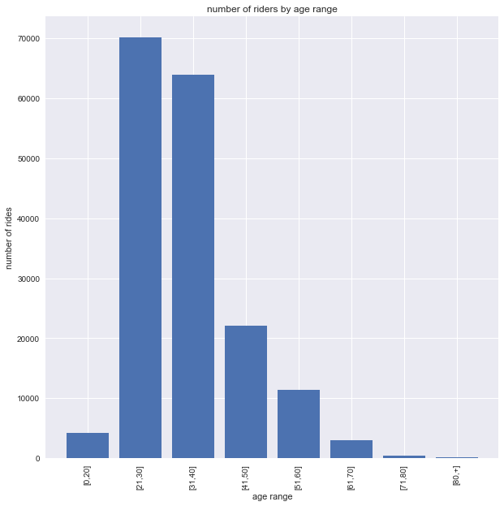

```python
plt.figure(figsize=(10,10))
plt.bar(height = values,x = labels)
plt.xticks(rotation = 90)
plt.title("number of riders by age range")
plt.xlabel("age range")
plt.ylabel("number of rides")
```

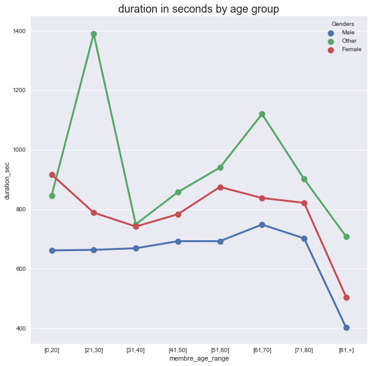

```python
plt.figure(figsize=(10,10))
sb.pointplot(data = df_use, x = 'membre_age_range', y ='duration_sec',
             hue = 'member_gender',ci = False );
plt.title('duration in seconds by age group', fontsize = 18);
plt.legend(title = 'Genders');
```

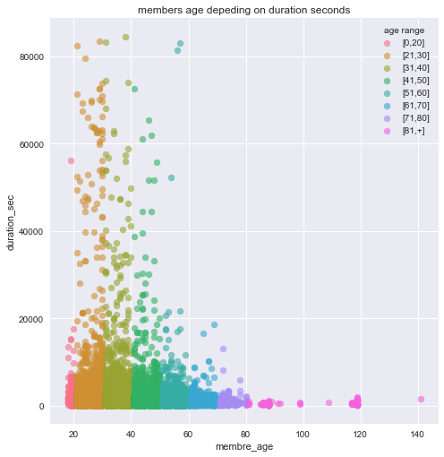

```python
g = sb.FacetGrid(data = df_use, hue = 'membre_age_range', height=7)
g.map(plt.scatter, 'membre_age', 'duration_sec',alpha = 0.6)
plt.legend(title = 'age range');
plt.title("members age depeding on duration seconds")
```

this plot looks very noisy let's try a different approach

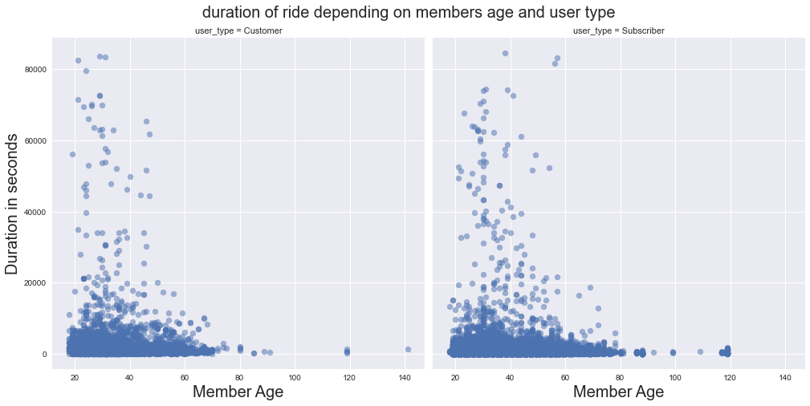

```python
g = sb.FacetGrid(data = df_use, col = 'user_type', col_wrap = 2,height=7)
g.map(plt.scatter, 'membre_age', 'duration_sec',alpha = 0.5)
g.set_xlabels('Member Age',size = 20)
g.set_ylabels('Duration in seconds',size = 20)
g.fig.subplots_adjust(top=0.9)
g.fig.suptitle('duration of ride depending on members age and user type',size = 20)
```

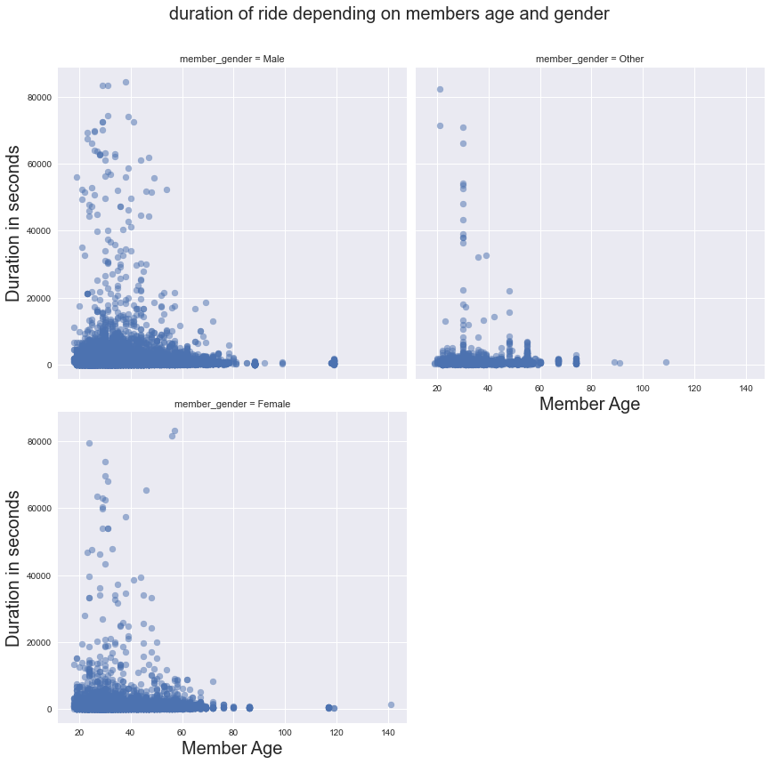

```python
g = sb.FacetGrid(data = df_use, col = 'member_gender',height = 6,col_wrap=2)
g.map(plt.scatter, 'membre_age', 'duration_sec',alpha = 0.5)
g.set_xlabels('Member Age',size = 20)
g.set_ylabels('Duration in seconds',size = 20)
g.fig.subplots_adjust(top=0.9)
g.fig.suptitle('duration of ride depending on members age and gender',size = 20)
```

again we find that Customers and subscribers have the same behaviour

```python
df_use.to_csv("dataset_final.csv")
```

# Conclusions

## other facts

- most users fall between 20-40 years old
- most users of this service are males
- most users of this service are subscribed